TASK 1 — Iris Flower Classification

Importing The Libraries

```python
import pandas as pd
import numpy as np
import matplotlib.pyplot as plt
import seaborn as sns

from sklearn.datasets import load_iris
from sklearn.model_selection import train_test_split
from sklearn.preprocessing import StandardScaler

from sklearn.linear_model import LogisticRegression
from sklearn.ensemble import RandomForestClassifier

from sklearn.metrics import (
    accuracy_score,
    confusion_matrix,
    classification_report
)
```

Loading The Dataset

```python
iris = load_iris()

X = iris.data
y = iris.target

print("Feature Names:")
print(iris.feature_names)

print("\nTarget Names:")
print(iris.target_names)
```

```
Feature Names:
['sepal length (cm)', 'sepal width (cm)', 'petal length (cm)', 'petal width (cm)']

Target Names:
['setosa' 'versicolor' 'virginica']
```

Create a DataFrame

```python
df = pd.DataFrame(
    X,
    columns=iris.feature_names
)

df["species"] = y

df["species"] = df["species"].map({
    0: "Setosa",
    1: "Versicolor",
    2: "Virginica"
})
```

Exploratory Data Analysis (EDA)

```python
print("Shape of dataset:", df.shape)
```

```
Shape of dataset: (150, 5)
```

Data Types

```python
df.dtypes
```

```
sepal length (cm)    float64
sepal width (cm)     float64
petal length (cm)    float64
petal width (cm)     float64
species               object
dtype: object
```

Dataset Informantion

```python
df.info()
```

```
<class 'pandas.core.frame.DataFrame'>
RangeIndex: 150 entries, 0 to 149
Data columns (total 5 columns):
 #   Column             Non-Null Count  Dtype
---  ------             --------------  -----
 0   sepal length (cm)  150 non-null    float64
 1   sepal width (cm)   150 non-null    float64
 2   petal length (cm)  150 non-null    float64
 3   petal width (cm)   150 non-null    float64
 4   species            150 non-null    object
dtypes: float64(4), object(1)
memory usage: 6.0+ KB
```

Check Null Values

```python
df.isna().sum()
```

```
sepal length (cm)    0
sepal width (cm)     0
petal length (cm)    0
petal width (cm)     0
species              0
dtype: int64
```

Descriptive Statistics

```python
df.describe()
```

|  | sepal length (cm) | sepal width (cm) | petal length (cm) | petal width (cm) |
| --- | --- | --- | --- | --- |
| count | 150.000000 | 150.000000 | 150.000000 | 150.000000 |
| mean | 5.843333 | 3.057333 | 3.758000 | 1.199333 |
| std | 0.828066 | 0.435866 | 1.765298 | 0.762238 |
| min | 4.300000 | 2.000000 | 1.000000 | 0.100000 |
| 25% | 5.100000 | 2.800000 | 1.600000 | 0.300000 |
| 50% | 5.800000 | 3.000000 | 4.350000 | 1.300000 |
| 75% | 6.400000 | 3.300000 | 5.100000 | 1.800000 |
| max | 7.900000 | 4.400000 | 6.900000 | 2.500000 |

Species Count

```python
print(df["species"].value_counts())
```

```
species
Setosa        50
Versicolor    50
Virginica     50
Name: count, dtype: int64
```

Visualizations

Pairplot

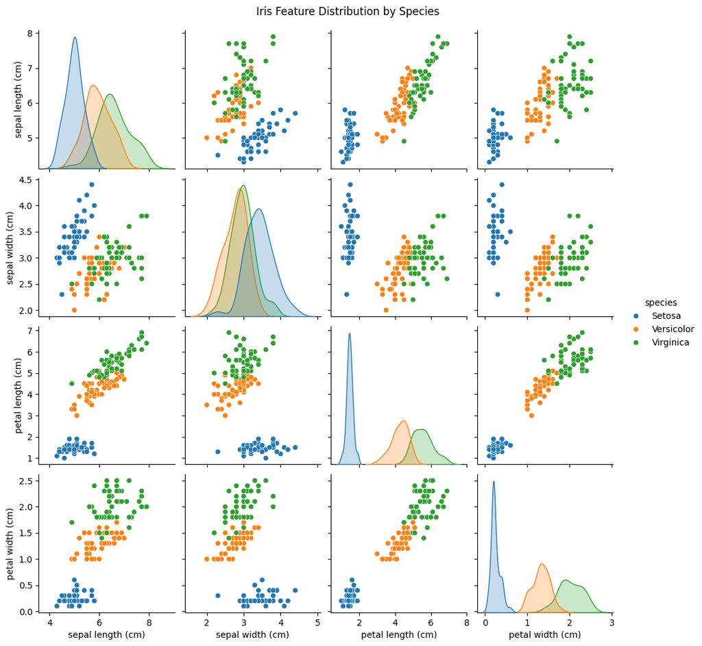

```python
sns.pairplot(
    df,
    hue="species"
)

plt.suptitle(
    "Iris Feature Distribution by Species",
    y=1.02
)

plt.show()
```

Box Plots

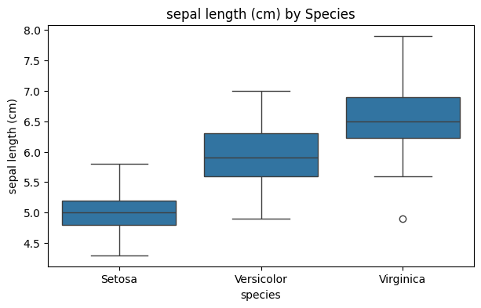

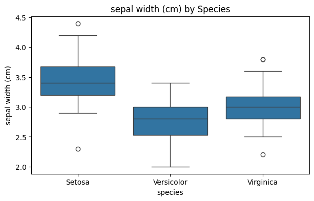

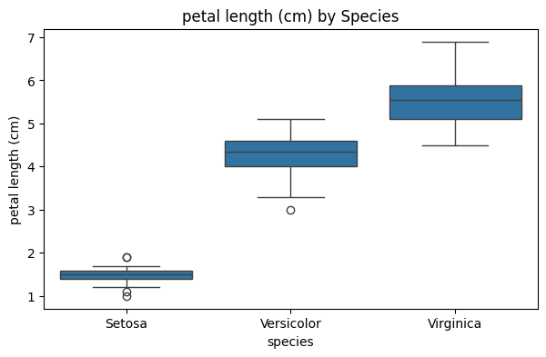

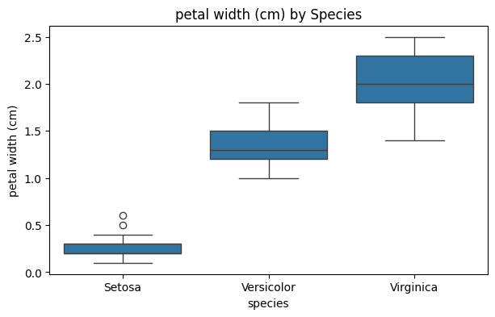

```python
features = iris.feature_names

for feature in features:
    plt.figure(figsize=(7, 4))

    sns.boxplot(
        data=df,
        x="species",
        y=feature
    )

    plt.title(f"{feature} by Species")
    plt.show()
```

Feature Selection Discussion

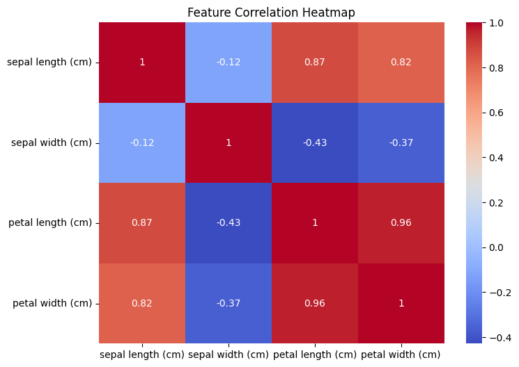

```python
plt.figure(figsize=(8, 6))

sns.heatmap(
    df[iris.feature_names].corr(),
    annot=True,
    cmap="coolwarm"
)

plt.title("Feature Correlation Heatmap")
plt.show()
```

Train/Test Split

```python
X = df[iris.feature_names]
y = iris.target

X_train, X_test, y_train, y_test = train_test_split(
    X,
    y,
    test_size=0.20,
    random_state=42,
    stratify=y
)

print("Training samples:", X_train.shape[0])
print("Testing samples:", X_test.shape[0])
```

```
Training samples: 120
Testing samples: 30
```

Feature Scaling

```python
scaler = StandardScaler()

X_train_scaled = scaler.fit_transform(X_train)
X_test_scaled = scaler.transform(X_test)
```

Model 1 — Logistic Regression

```python
logistic_model = LogisticRegression(
    max_iter=200
)

logistic_model.fit(
    X_train_scaled,
    y_train
)

y_pred_lr = logistic_model.predict(
    X_test_scaled
)
```

Accuracy

```python
accuracy_lr = accuracy_score(
    y_test,
    y_pred_lr
)

print("Logistic Regression Accuracy:",
      accuracy_lr)
```

```
Logistic Regression Accuracy: 0.9333333333333333
```

Classification Report

```python
print(
    classification_report(
        y_test,
        y_pred_lr,
        target_names=iris.target_names
    )
)
```

```
              precision    recall  f1-score   support

      setosa       1.00      1.00      1.00        10
  versicolor       0.90      0.90      0.90        10
   virginica       0.90      0.90      0.90        10

    accuracy                           0.93        30
   macro avg       0.93      0.93      0.93        30
weighted avg       0.93      0.93      0.93        30
```

Logistic Regression Confusion Matrix

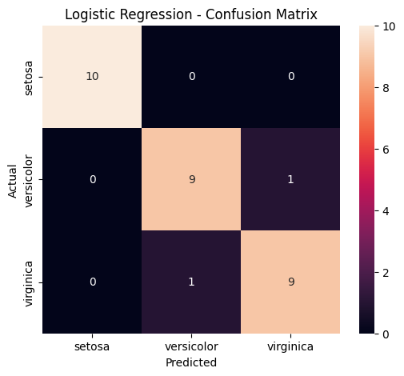

```python
cm_lr = confusion_matrix(
    y_test,
    y_pred_lr
)

plt.figure(figsize=(6, 5))

sns.heatmap(
    cm_lr,
    annot=True,
    fmt="d",
    xticklabels=iris.target_names,
    yticklabels=iris.target_names
)

plt.xlabel("Predicted")
plt.ylabel("Actual")
plt.title("Logistic Regression - Confusion Matrix")

plt.show()
```

Model 2 — Random Forest

```python
rf_model = RandomForestClassifier(
    n_estimators=100,
    random_state=42
)

rf_model.fit(
    X_train,
    y_train
)

y_pred_rf = rf_model.predict(
    X_test
)
```

Accuracy

```python
accuracy_rf = accuracy_score(
    y_test,
    y_pred_rf
)

print("Random Forest Accuracy:",
      accuracy_rf)
```

```
Random Forest Accuracy: 0.9
```

Classification Report

```python
print(
    classification_report(
        y_test,
        y_pred_rf,
        target_names=iris.target_names
    )
)
```

```
              precision    recall  f1-score   support

      setosa       1.00      1.00      1.00        10
  versicolor       0.82      0.90      0.86        10
   virginica       0.89      0.80      0.84        10

    accuracy                           0.90        30
   macro avg       0.90      0.90      0.90        30
weighted avg       0.90      0.90      0.90        30
```

Random Forest Confusion Matrix

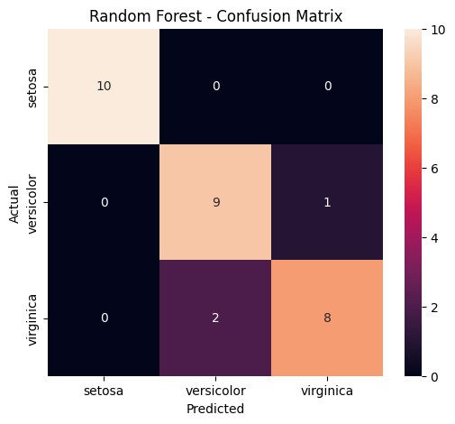

```python
cm_rf = confusion_matrix(
    y_test,
    y_pred_rf
)

plt.figure(figsize=(6, 5))

sns.heatmap(
    cm_rf,
    annot=True,
    fmt="d",
    xticklabels=iris.target_names,
    yticklabels=iris.target_names
)

plt.xlabel("Predicted")
plt.ylabel("Actual")
plt.title("Random Forest - Confusion Matrix")

plt.show()
```

Compare Both Models

```python
results = pd.DataFrame({
    "Model": [
        "Logistic Regression",
        "Random Forest"
    ],
    "Accuracy": [
        accuracy_lr,
        accuracy_rf
    ]
})

results
```

|  | Model | Accuracy |
| --- | --- | --- |
| 0 | Logistic Regression | 0.933333 |
| 1 | Random Forest | 0.900000 |

Visualization

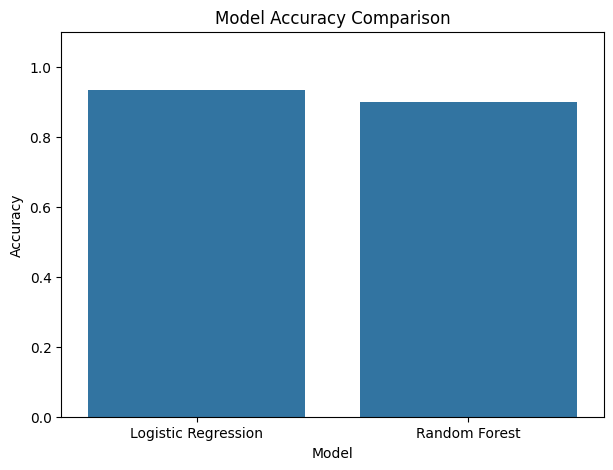

```python
plt.figure(figsize=(7, 5))

sns.barplot(
    data=results,
    x="Model",
    y="Accuracy"
)

plt.ylim(0, 1.1)
plt.title("Model Accuracy Comparison")
plt.ylabel("Accuracy")

plt.show()
```

Feature Importance — Random Forest

```python
feature_importance = pd.Series(
    rf_model.feature_importances_,
    index=iris.feature_names
).sort_values(ascending=False)

print(feature_importance)
```

```
petal width (cm)     0.437185
petal length (cm)    0.431466
sepal length (cm)    0.116349
sepal width (cm)     0.015000
dtype: float64
```

Visualize

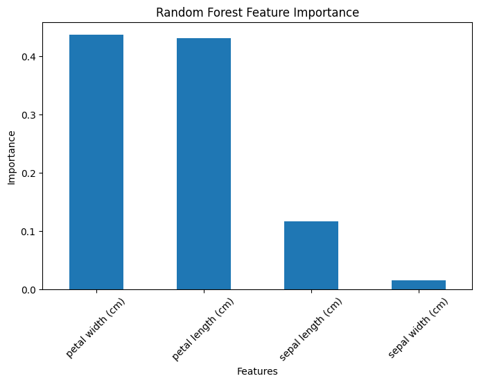

```python
plt.figure(figsize=(8, 5))

feature_importance.plot(kind="bar")

plt.title("Random Forest Feature Importance")
plt.xlabel("Features")
plt.ylabel("Importance")

plt.xticks(rotation=45)
plt.show()
```

Identify Best Model

```python
best_model = results.loc[
    results["Accuracy"].idxmax()
]

print("Best Performing Model:",
      best_model["Model"])

print("Best Accuracy:",
      best_model["Accuracy"])
```

```
Best Performing Model: Logistic Regression
Best Accuracy: 0.9333333333333333
```

Final Conclusion

Put this in a Markdown cell:

Conclusion: In this project, Logistic Regression and Random Forest classification models were trained to predict Iris flower species. Both models were evaluated using accuracy, confusion matrices, precision, recall, and F1-score. Based on the test-set results, the model with the highest accuracy was selected as the best-performing model. The analysis also showed that petal length and petal width are highly discriminative features for distinguishing between Setosa, Versicolor, and Virginica.